# Assignment 1 - Network Analysis

Balint Bojko

2018 november 2

Please note:

I couldn’t knit the file into a pdf for some reason. I got this error:

Output created: Assignment_1.pdf Error in tools::file_path_as_absolute(output_file) : file ‘Assignment_1.pdf’ does not exist Calls: -> In addition: Warning messages: 1: running command ‘“pdflatex” -halt-on-error -interaction=batchmode “Assignment_1.tex”’ had status 1 In readLines(log) : incomplete final line found on ‘Assignment_1.log’ 3: In readLines(logfile) : incomplete final line found on ‘Assignment_1.log’ Execution halted

Do you know why this could be?

## Question 1

### a,

The following code gives NA, because NA values in included in the computation process.

```r
a <- c(8, NA, 20, 5, 7, 9)
mean(a)
```

```
## [1] NA
```

We need to drop the NA, by including na.rm in the mean function.

```r
mean(a,na.rm = T)
```

```
## [1] 9.8
```

### b,

Now, remove the NA from the vector instead and compute the mean.

```r
a <- a[-2]
mean(a)
```

```
## [1] 9.8
```

## Question 2

### a,

```r
matrix_Q2 <- matrix(c(0,1,1,1,rep(0,12)),4,4,byrow = T)
```

### b,

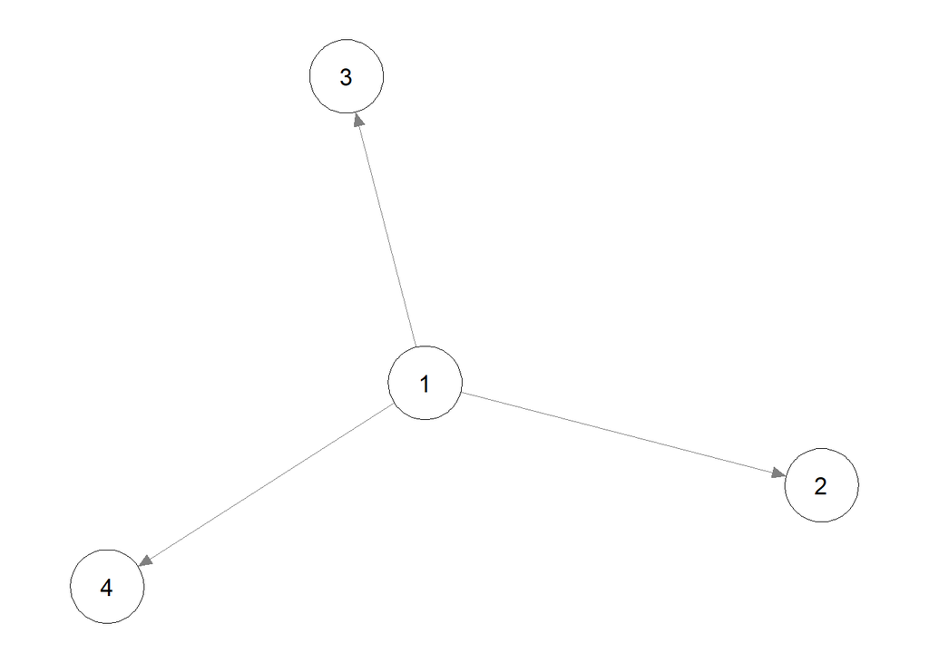

```r
library(qgraph)
qgraph(matrix_Q2)
```

## Question 3

### a,

```r
library(psych)
# Load bfi dataset:
data(bfi)
# Look at data:
View(bfi)
```

More information about the data set can be found by running ‘?bfi’ from the console.

### b,

Number of men

```r
sum(bfi$gender==1)
```

```
## [1] 919
```

Number of women

```r
sum(bfi$gender==2)
```

```
## [1] 1881
```

### c,

Mean age of subjects

```r
mean(bfi$age)
```

```
## [1] 28.78214
```

### d,

Found information about EFA function in the psych package description (‘?psych’) / (‘?psych::fa’)

Creating new dataset

```r
data_Q3 <- bfi[,1:25]
fa_Q3 <- fa(data_Q3, rotate = 'promax')
```

### e,

Creating plot with loadings

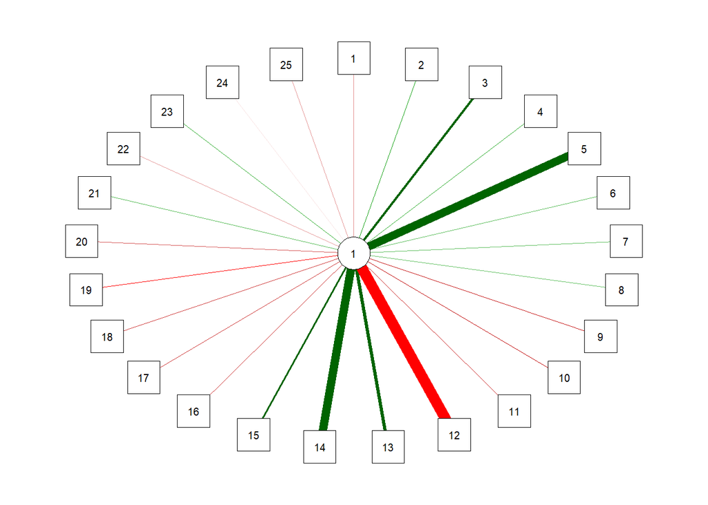

```r
qgraph.loadings(unclass(fa_Q3$loadings))
```

## Question 4

### a,

Setting the working directory from the menu: Session/Set Working Directory/To Source File Location

### b,

Loading SPSS file

```r
library(foreign)
data_Q4 <- read.spss('job_performance.sav',to.data.frame = T)
```

### c,

```r
cor(data_Q4[,-1])
```

```
##           perf          iq        mot         soc
## perf 1.0000000  0.47378037 0.63486569  0.39692818
## iq   0.4737804  1.00000000 0.04687791 -0.09180517
## mot  0.6348657  0.04687791 1.00000000  0.36339641
## soc  0.3969282 -0.09180517 0.36339641  1.00000000
```

### d,

Fitting linear regression with job performance as the outcome variable, and IQ, motivation and social support as predictors.

```r
fit <- lm(perf ~ iq + mot + soc, data = data_Q4)
```

### e,

Investigating object fit

```r
summary(fit)
```

```
##
## Call:
## lm(formula = perf ~ iq + mot + soc, data = data_Q4)
##
## Residuals:
##      Min       1Q   Median       3Q      Max
## -11.1376  -2.8375  -0.1956   3.4518  11.1904
##
## Coefficients:
##             Estimate Std. Error t value Pr(>|t|)
## (Intercept) 18.13146    6.34603   2.857  0.00599 **
## iq           0.26487    0.04440   5.965 1.73e-07 ***
## mot          0.30820    0.05001   6.163 8.24e-08 ***
## soc          0.16396    0.05551   2.953  0.00459 **
## ---
## Signif. codes:  0 '***' 0.001 '**' 0.01 '*' 0.05 '.' 0.1 ' ' 1
##
## Residual standard error: 4.844 on 56 degrees of freedom
## Multiple R-squared:  0.6545, Adjusted R-squared:  0.636
## F-statistic: 35.36 on 3 and 56 DF,  p-value: 5.908e-13
```

All three predictors are significant with and without adjusting for multiple testing (Bonferroni). Quick question: do you need to adjust for multiple testing in this case?

## Question 5

### a,

```r
data_Q5 <- read.spss('PTSDdata.sav',to.data.frame = T)
data_Q5 <- data_Q5[,10:30]
```

### b,

```r
colnames(data_Q5) <- c('Lifetime Trauma',
                       'Intrusive thoughts',
                       'Nightmares',
                       'Flashbacks',
                       'Emotional cue reactivity',
                       'Psychological cue reactivity',
                       'Avoidance of thoughts',
                       'Avoidance of reminders',
                       'Trauma-related amnesia',
                       'Negative beliefs',
                       'Blame of self or others',
                       'Negative trauma-related emotions',
                       'Loss of interest',
                       'Detachment',
                       'Restricted affect',
                       'Irritability / anger',
                       'Self-destructive / reckless behaviour',
                       'Hypervigilance',
                       'Exaggerated startle response',
                       'Difficulty concentrating',
                       'Sleep disturbance')
head(data_Q5)
```

```
##   Lifetime Trauma Intrusive thoughts Nightmares Flashbacks
## 1               7                  1          0          1
## 2               7                  2          3          2
## 3               5                  1          0          0
## 4               4                  2          2          0
## 5              10                  2          1          0
## 6              14                  4          3          3
##   Emotional cue reactivity Psychological cue reactivity
## 1                        2                            1
## 2                        2                            2
## 3                        1                            0
## 4                        0                            1
## 5                        2                            2
## 6                        4                            3
##   Avoidance of thoughts Avoidance of reminders Trauma-related amnesia
```

[output cut: 41 more lines]

### c,

```r
round(cor(data_Q5[,-1]),2)
```

```
##                                       Intrusive thoughts Nightmares
## Intrusive thoughts                                  1.00       0.52
## Nightmares                                          0.52       1.00
## Flashbacks                                          0.51       0.67
## Emotional cue reactivity                            0.59       0.45
## Psychological cue reactivity                        0.52       0.49
## Avoidance of thoughts                               0.21       0.23
## Avoidance of reminders                              0.34       0.40
## Trauma-related amnesia                              0.19       0.16
## Negative beliefs                                    0.28       0.14
## Blame of self or others                             0.35       0.31
## Negative trauma-related emotions                    0.52       0.41
## Loss of interest                                    0.37       0.38
## Detachment                                          0.29       0.30
## Restricted affect                                   0.21       0.17
## Irritability / anger                                0.39       0.31
## Self-destructive / reckless behaviour               0.23       0.37
## Hypervigilance                                      0.20       0.29
## Exaggerated startle response                        0.25       0.43
## Difficulty concentrating                            0.30       0.27
## Sleep disturbance                                   0.32       0.41
##                                       Flashbacks Emotional cue reactivity
## Intrusive thoughts                          0.51                     0.59
## Nightmares                                  0.67                     0.45
## Flashbacks                                  1.00                     0.55
## Emotional cue reactivity                    0.55                     1.00
## Psychological cue reactivity                0.55                     0.61
## Avoidance of thoughts                       0.25                     0.34
## Avoidance of reminders                      0.40                     0.44
## Trauma-related amnesia                      0.16                     0.14
## Negative beliefs                            0.20                     0.27
## Blame of self or others                     0.32                     0.41
## Negative trauma-related emotions            0.43                     0.47
## Loss of interest                            0.42                     0.21
## Detachment                                  0.30                     0.12
## Restricted affect                           0.25                     0.05
## Irritability / anger                        0.37                     0.34
## Self-destructive / reckless behaviour       0.31                     0.19
## Hypervigilance                              0.36                     0.22
## Exaggerated startle response                0.45                     0.29
```

[output cut: 302 more lines]

```
## Avoidance of thoughts                              0.14
## Avoidance of reminders                             0.19
## Trauma-related amnesia                             0.11
## Negative beliefs                                   0.21
## Blame of self or others                            0.19
## Negative trauma-related emotions                   0.26
## Loss of interest                                   0.37
## Detachment                                         0.42
## Restricted affect                                  0.31
## Irritability / anger                               0.29
## Self-destructive / reckless behaviour              0.20
## Hypervigilance                                     0.30
## Exaggerated startle response                       0.40
## Difficulty concentrating                           0.44
## Sleep disturbance                                  1.00
```

### d,

```r
sum(data_Q5$Nightmares)
```

```
## [1] 266
```

```r
sum(data_Q5$`Sleep disturbance`)
```

```
## [1] 492
```

### e,

```r
cor.test(data_Q5$`Lifetime Trauma`,data_Q5$Nightmares)
```

```
##
##  Pearson's product-moment correlation
##
## data:  data_Q5$`Lifetime Trauma` and data_Q5$Nightmares
## t = 2.8272, df = 219, p-value = 0.005131
## alternative hypothesis: true correlation is not equal to 0
## 95 percent confidence interval:
##  0.05709149 0.31189628
## sample estimates:
##       cor
## 0.1876489
```

The correlation is significant, however, can be considered ‘weak’ only. Cor = 0.19, p = 0.005

### f,

```r
library(ppcor)
pcor.test(data_Q5$`Lifetime Trauma`,data_Q5$Nightmares,data_Q5$`Negative trauma-related emotions`)
```

```
##   estimate    p.value statistic   n gp  Method
## 1 0.164003 0.01488306  2.454713 221  1 pearson
```

The p-value is still significant at alpha = 0.05, however, it is higher with the control variable included. Cor = 0.164, p = 0.015. This happened because some of the shared variance between the two variables can be explained by the control variable.

## Bonus question

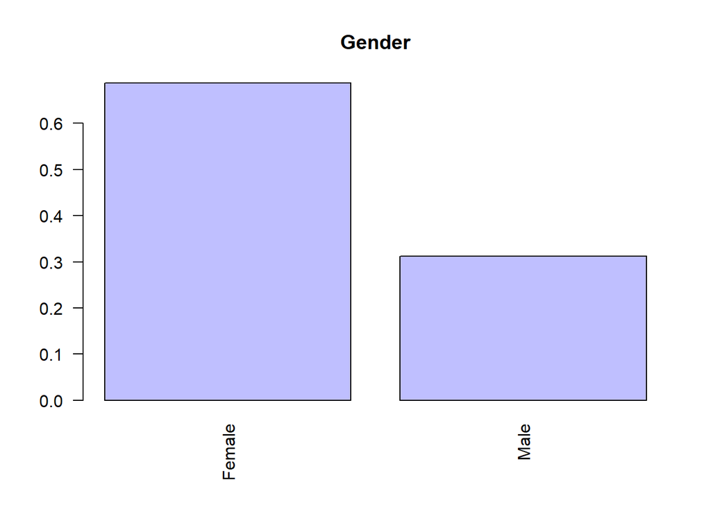

```r
data_bonus <- read.csv('studentdata.csv',sep=';')


barplot(prop.table(table(data_bonus$What.is.your.gender.)),  col=rgb(0,0,1,1/4),
        main = 'Gender', las = 2)
```

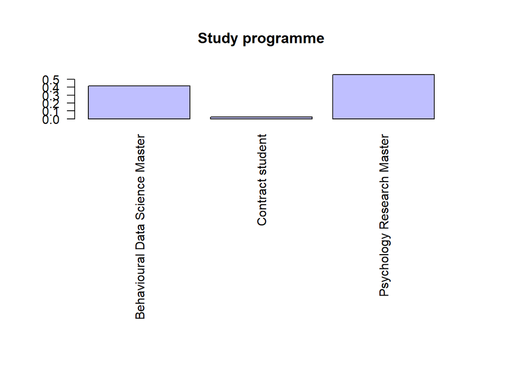

```r
par(mfrow = c(1,1), mar = c(17,5,5,5))


barplot(prop.table(table(data_bonus$I.am.a.student.in.the.)),  col=rgb(0,0,1,1/4),
        main = 'Study programme', las = 2)
```

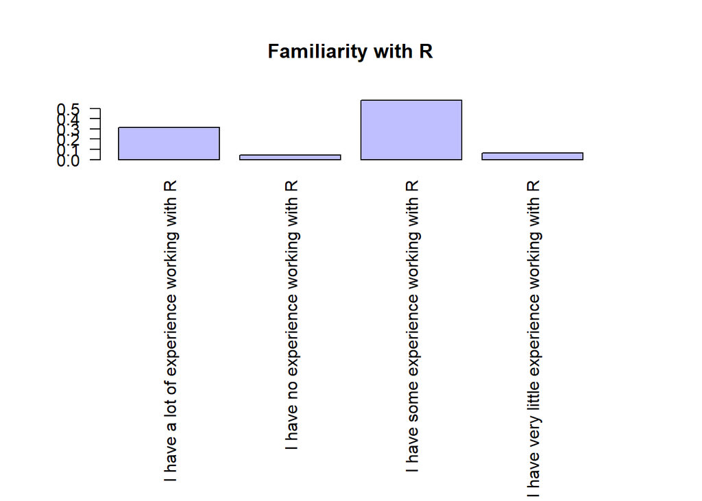

```r
barplot(prop.table(table(data_bonus$How.familiar.are.you.with.R.)),  col=rgb(0,0,1,1/4),
        main = 'Familiarity with R', las = 2)
```

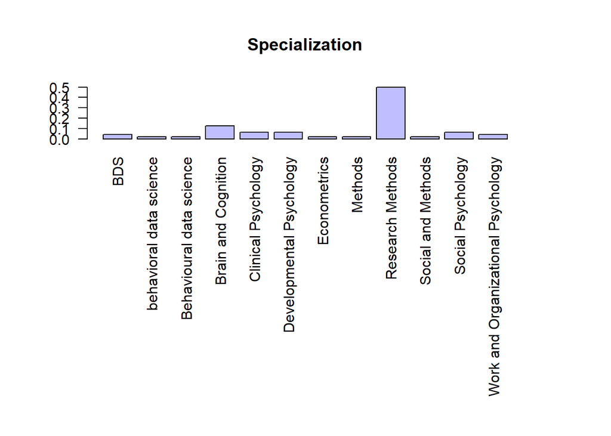

```r
barplot(prop.table(table(data_bonus$What.is..are..your.specialization.s..)),  col=rgb(0,0,1,1/4),
        main = 'Specialization', las = 2)
```

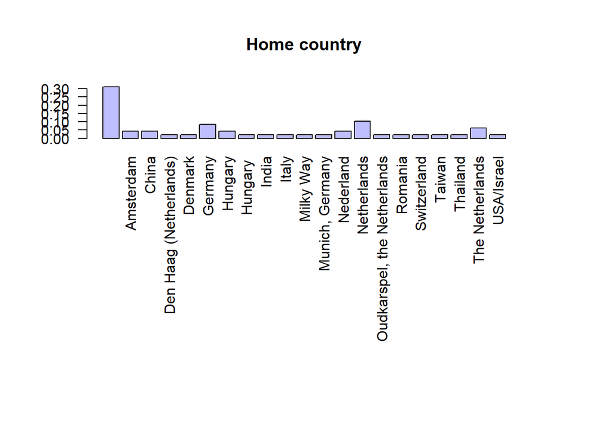

```r
barplot(prop.table(table(data_bonus$Where.are.you.from.)),  col=rgb(0,0,1,1/4),
        main = 'Home country', las = 2)
```